### A Simulation Exercise and the Central Limit Theorem

Jim White  
November 17, 2015

#### Overview:

This project investigated the exponential distribution in R and compared it with the Central Limit Theorem. For the purposes of this demonstration lambda = 0.2 and the investigation includes the distribution of averages of 40 exonentials over 1000 simulations. Explanation is provided regarding the properties of the mean and variance of the 40 exponentials.

#### Sumulations

**Exponential Distribution:** “the probability distribution that describes the time between events in a Poisson process, i.e. a process in which events occur continuously and independently at a constant average rate.” From [Wikipedia](https://en.wikipedia.org/wiki/Exponential_distribution).

The exponential distribution can be simulated in R with rexp(n, lambda) where lambda is the rate parameter. The expected value ($\mu$) of the exponential distribution is E[X] = $\frac{1}{\lambda}$. The variance of X is represented by Var[X] = $\frac{1}{\lambda^2}$. Consequently the standard deviation is $\frac{1}{\lambda}$.

To briefly examine a visual representation of the exponential distribution, let lambda be equal to the values of 1, 2, & 3. For the value of x we will create 100 random values between 0 and 5 for each of the $\lambda$ values. The f(x) value will be expressed as follows: f(x;$\lambda) = \lambda e^{-\lambda x}$

The figure exponential distribution simluations can be found on the firts page of the Appendix.

**Demonstration of the Central limit Theorem (CLT)**

A definition of the **Central Limit Theorem:** “states that, given certain conditions, the arithmetic mean of a sufficiently large number of iterates of independent random variables, each with a well-defined expected value and well-defined variance, will be approximately normally distributed.” From [Wikipedia](https://en.wikipedia.org/wiki/Central_limit_theorem).

Even though the exponential distribution does not represent a normally distributed curve, the following simulation(s) will show, through the use of the *Law of Large Numbers*, that taking a large number of random samples from the distribution will result in the averages (and standard deviations) of those samples approaching a normal distribution.

Or as stated within slide 7/31 from the *Asymptotics and LLN* lecture:

**$\large \sqrt{n} (\bar{X}_n - \mu) / \sigma$**  
orr  
**$\large \bar{X} \sim N(\mu,\frac{\sigma^2}{n})$**  
-——————————————————————  
**Simulation Samples Taken from the Exponential Distribution**  
As an indicator for the CTL, a simulation will be completed in which $\lambda$ = 0.2, 1000 simulations are used representing 40 exponentials.

As shown, in Figure 1 (below), the mean of the simulated samples appear in the histogram to approach a normal distribution. To further emphasize the red line within the figure is a kernel density plot of the simulated means data. The blue line represents the mean of the simulation. In addition, a Q-Q Plot (a probability plot) was constructed to examine normal distribution. Departures from a straightline create via the qqline function indicates departures from normality. From [Cookbook for R](https://en.wikipedia.org/wiki/Shapiro%E2%80%93Wilk_test).

**Figure 1: Simulated Mean Samples**

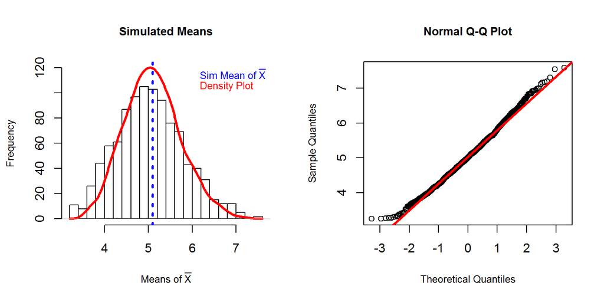

The Q-Q Plot indicates some variation in the tails of the dataset.

```
##
##  Shapiro-Wilk normality test
##
## data:  sim_means
## W = 0.99398, p-value = 0.0004781
```

From the Shapiro-Wilk test, the p-value indicates that there is only a small chance (0.0004781) that the data is normal. But $\bar{X} \approx \mu$ and $s \approx\sigma$ may still be true.

For the exponential distribution, the theoretical (or expected) mean ($\mu$) = $\frac{1}{\lambda}$. If $\lambda$ = 0.2, then the $\mu$ = 5.

To determine if the sample means approximate the theoretical (or expected) mean, a confidence interval is taken at the 95% interval for the sample:

```
## [1] 4.994940 5.091166
```

Thus since the theoretical (or expected) mean (of 5) falls within the confidence interval, the hypothesis that $\bar{X} \neq \mu$ can be rejected.

**Simulation of the variance:**  
Next to analyze the variance of the simulation. The theoretical or expected variance for the exponential distribution is equal to $\large \frac{1}{\lambda^{2}}$ or ($1/.2^2 = 25$).

**Figure 2: Simulated Variance Samples**

[figure not shown]

As with the mean, the variance indicates a variation (though somewhat larger) from normal within the tails. This is also evident when examining Figure 2. Next to examine the Shapiro - Wilk test.

```
##
##  Shapiro-Wilk normality test
##
## data:  sim_var
## W = 0.87442, p-value < 2.2e-16
```

The Shapiro-Wilk test indicates the distribution is not normal.

To determine if the sample mean of the variances approximate the theoretical (or expected) variance, a confidence interval is taken at the 95% interval for the sample:

```
## [1] 24.94734 26.42501
```

Thus since the theoretical (Or expected) variance (of 25) falls within the confidence interval, the hypothesis that $s^{2} \neq \sigma^{2}$ can be rejected.

**Conclusion:** Consequently, it can be concluded that the Central Limit Theorem appears to be true.

### Appendix

**Code and Figure: The Exponential Distribution (an example)**

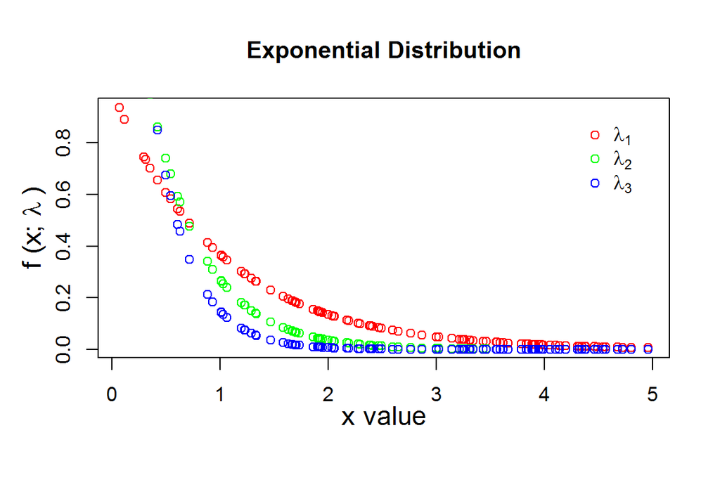

```r
set.seed(1) # to ensure reproducibility
# randomly select values for x
x <- runif(100, 0, 5)
# set lambda values and calculate respective y values
lambda <- 1
while(lambda <= 3){
    #Calculate the y values
    assign(paste("y", lambda, sep = ""),
           lambda*exp(-lambda*x))
    lambda <- lambda + 1
    }
# plot the three x.y groups as points
par(cex.lab=1.3, mgp = c(2, 1, 0))
plot(x, y1, type = "p", col = "red", main = "Exponential Distribution",
     xlab = "x value", ylab = expression(paste("f (x; ", lambda," )")))

points(x, y2, col = "green")
points(x, y3, col = "blue")
legend("topright", c(expression(lambda[1]), expression(lambda[2]), expression(lambda[3])), col = c("red", "green", "blue"), bty = "n", inset = .05, pch = 1, cex = 1.0)
```

As can be seen from the figure, the exponential ditribution is basically an asymptote. In addition, as the value of $lambda$ -> 0, the line approaches a straight-line model.

**R Code for creating figures within the document**

For Figure 2 Simulated Variance Samples

```r
# run simulation
set.seed(5)  # set seed for randomization for reproducibility
lambda <- 0.2  # set value of constant lambda
sample_size <- 40  # set sample size
sim <- 1000  # set number of simulations to run
sim_var <- replicate(sim, var(rexp(sample_size, lambda))) # run simulation

# create plots
par(mfrow = c(1, 2)) # set parameters
# histogram of simulation
hist(sim_var, breaks = 30, main = "Simulated Variances",
    xlab = expression(paste("Means of ", s^{2})), ylim = c(0, 200), cex.main = 0.9,
    cex.lab = 0.8)
par(new = TRUE)
# density plot of simulation
plot(density(sim_var), axes = FALSE, bty = "n", xlab="", ylab="", col = "red", lwd = 3,
     main = "")
# line representing mean of simulation
abline(v = mean(sim_var), col = "blue", lwd = 3, lty = 3, xpd = FALSE)
# create legend
x <- toString(round(mean(sim_var), 1))
legend("topright", legend = c(paste("Sim Mean of var = ", x), " ", "Density Plot"),
     text.col = c("blue", "white", "red"), bty = "n", cex = .8)
par(new = FALSE)

## create Q-Q Plot
par(cex.main = 0.9, cex.lab = .8)
qqnorm(sim_var)
qqline(sim_var, col = "red", lwd = 3, xpd = FALSE)
```

Code for running the Shapiro Tests

```r
shapiro.test(sim_means)
```

```r
shapiro.test(sim_var)
```

Code for the confidence intervals

```r
mean(sim_means) + c(-1, 1)*qnorm(0.975)*sd(sim_means)/sqrt(length(sim_means))
```

```r
mean(sim_var) + c(-1, 1)*qnorm(0.975)*sd(sim_var)/sqrt(length(sim_var))
```